# Spatial Analysis and Mapping

From Raw Data to Regional Insights: Intermediate R Tools for Workforce & Economic Development

Nov 19-20, 2025

# 1. Introduction

This module introduces a practical spatial workflow for workforce and economic development:

1. Download geographic boundaries using **tigris**
2. Work with spatial data using **sf**
3. Map ACS variables with **tidycensus**
4. Map **BLS LAUS unemployment rates** at the county level
5. Produce static and interactive maps

# 2. TIGER/Line Shapefiles with `tigris`

`tigris` gives direct access to U.S. Census geographic boundaries.

```r
nj_counties <- counties(state = "NJ", cb = TRUE, year = 2023)
```

```r
nj_counties
```

|  | STATEFP | COUNTYFP | COUNTYNS | GEOIDFQ | GEOID | NAME | NAMELSAD | STUSPS | STATE_NAME | LSAD | ALAND | AWATER | geometry |
| --- | --- | --- | --- | --- | --- | --- | --- | --- | --- | --- | --- | --- | --- |
| 76 | 34 | 015 | 00882277 | 0500000US34015 | 34015 | Gloucester | Gloucester County | NJ | New Jersey | 06 | 833996720 | 38239948 |  |
| 214 | 34 | 027 | 00882231 | 0500000US34027 | 34027 | Morris | Morris County | NJ | New Jersey | 06 | 1194048303 | 53103740 |  |
| 476 | 34 | 009 | 00882274 | 0500000US34009 | 34009 | Cape May | Cape May County | NJ | New Jersey | 06 | 651437193 | 955149826 |  |
| 477 | 34 | 023 | 00882230 | 0500000US34023 | 34023 | Middlesex | Middlesex County | NJ | New Jersey | 06 | 800946849 | 35297517 |  |
| 478 | 34 | 007 | 00882273 | 0500000US34007 | 34007 | Camden | Camden County | NJ | New Jersey | 06 | 573324567 | 15689888 |  |
| 674 | 34 | 035 | 00882234 | 0500000US34035 | 34035 | Somerset | Somerset County | NJ | New Jersey | 06 | 781832066 | 7993022 |  |
| 726 | 34 | 011 | 00882275 | 0500000US34011 | 34011 | Cumberland | Cumberland County | NJ | New Jersey | 06 | 1251948172 | 503663199 |  |
| 727 | 34 | 025 | 00882910 | 0500000US34025 | 34025 | Monmouth | Monmouth County | NJ | New Jersey | 06 | 1212642647 | 500373882 |  |
| 728 | 34 | 021 | 00882229 | 0500000US34021 | 34021 | Mercer | Mercer County | NJ | New Jersey | 06 | 581395408 | 11337168 |  |
| 1057 | 34 | 033 | 00882233 | 0500000US34033 | 34033 | Salem | Salem County | NJ | New Jersey | 06 | 859515221 | 105389623 |  |

[output cut: 11 more lines]

Quick visualization:

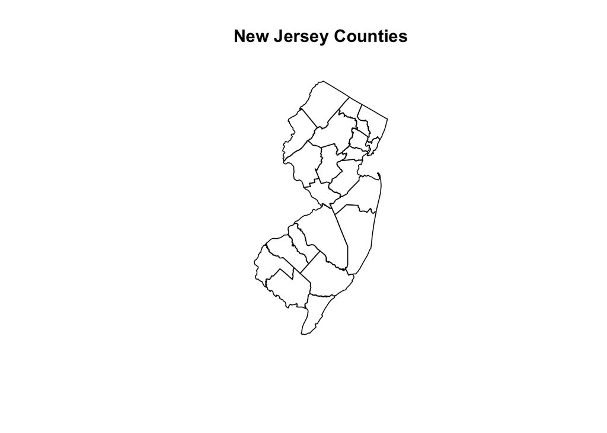

```r
plot(nj_counties$geometry, main = "New Jersey Counties")
```

## Exercises

1. Change the state to **PA** and download Pennsylvania counties.
2. Plot the county boundaries using `plot()`.
3. Try setting `cb = FALSE` and compare the detail level.

# 3. Basics of Spatial Data with `sf`

`sf` is the standard data structure for spatial analysis in R.

## 3.1 Inspecting an `sf` object

```r
class(nj_counties)
```

```
## [1] "sf"         "data.frame"
```

```r
st_geometry_type(nj_counties)
```

```
##  [1] MULTIPOLYGON MULTIPOLYGON MULTIPOLYGON MULTIPOLYGON MULTIPOLYGON
##  [6] MULTIPOLYGON MULTIPOLYGON MULTIPOLYGON MULTIPOLYGON MULTIPOLYGON
## [11] MULTIPOLYGON MULTIPOLYGON MULTIPOLYGON MULTIPOLYGON MULTIPOLYGON
## [16] MULTIPOLYGON MULTIPOLYGON MULTIPOLYGON MULTIPOLYGON MULTIPOLYGON
## [21] MULTIPOLYGON
## 18 Levels: GEOMETRY POINT LINESTRING POLYGON MULTIPOINT ... TRIANGLE
```

```r
st_crs(nj_counties)
```

```
## Coordinate Reference System:
##   User input: NAD83
##   wkt:
## GEOGCRS["NAD83",
##     DATUM["North American Datum 1983",
##         ELLIPSOID["GRS 1980",6378137,298.257222101,
##             LENGTHUNIT["metre",1]]],
##     PRIMEM["Greenwich",0,
##         ANGLEUNIT["degree",0.0174532925199433]],
##     CS[ellipsoidal,2],
##         AXIS["latitude",north,
##             ORDER[1],
##             ANGLEUNIT["degree",0.0174532925199433]],
##         AXIS["longitude",east,
##             ORDER[2],
##             ANGLEUNIT["degree",0.0174532925199433]],
##     ID["EPSG",4269]]
```

## 3.2 Converting a data frame → sf points

```r
centers_df <- tibble(
  name = c("Newark Office", "Trenton Office"),
  lon  = c(-74.17, -74.75),
  lat  = c(40.73, 40.22)
)

centers_sf <- st_as_sf(
  centers_df,
  coords = c("lon", "lat"),
  crs    = 4326
)

centers_sf
```

|  | name | geometry |
| --- | --- | --- |
| 1 | Newark Office |  |
| 2 | Trenton Office |  |

## 3.3 Plotting sf layers with ggplot2

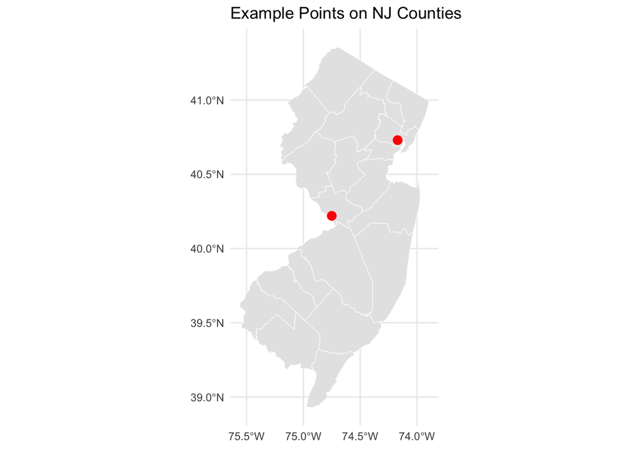

```r
ggplot() +
  geom_sf(data = nj_counties, fill = "grey90", color = "white") +
  geom_sf(data = centers_sf, color = "red", size = 3) +
  labs(title = "Example Points on NJ Counties") +
  theme_minimal()
```

## Exercises

1. Create an sf object of **three additional points** (any coordinates).
2. Plot them on top of your county map.
3. Use `st_transform(..., 3857)` to convert to a projected CRS.

# 4. Mapping Census/ACS Data with `tidycensus`

Set your Census API key:

```r
census_api_key(Sys.getenv("CENSUS_API_KEY"), install = TRUE, overwrite=TRUE)
```

## 4.1 Example: Median Household Income (New Jersey)

```r
nj_income <- get_acs(
  state     = "34",
  geography = "county",
  variables = "B19013_001",
  geometry  = TRUE,
  year      = 2020
)
```

Map the results:

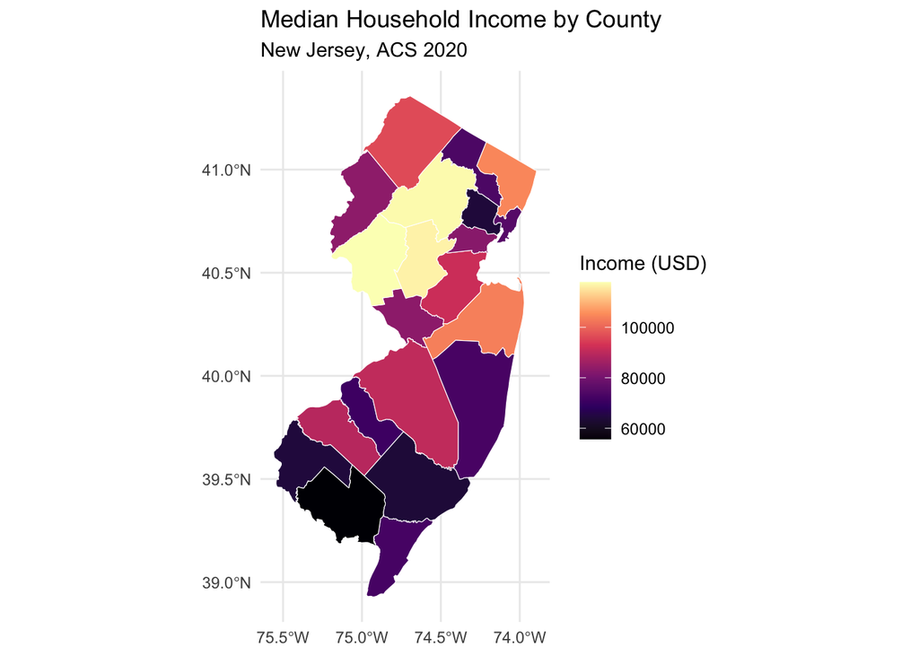

```r
nj_income %>%
  ggplot(aes(fill = estimate)) +
  geom_sf(color = "white") +
  scale_fill_viridis_c(option = "magma") +
  labs(
    title = "Median Household Income by County",
    subtitle = "New Jersey, ACS 2020",
    fill = "Income (USD)"
  ) +
  theme_minimal()
```

## Exercises

1. Replace `B19013_001` with **poverty rate** (`B17001_002`).
2. Map the variable using the same ggplot template.
3. Change the palette to `"viridis"` or `"plasma"`.

# 5. Mapping BLS Data (LAUS) for Unemployment Rate

This is one of the most useful applied mapping workflows for workforce & labor analysis.

## 5.1 Download county-level unemployment (LAUS API)

County-level LAUS series follow this pattern:

[output not shown]

Example: New Jersey (state FIPS = 34).

```r
nj_fips <- nj_counties$COUNTYFP
laus_ids <- paste0("LAUCN34", nj_fips, "0000000003")
```

Call the API:

```r
bls_key <- Sys.getenv("BLS_API_KEY")

laus_raw <- blsAPI(
  list(
    seriesid       = laus_ids,
    startyear      = 2024,
    endyear        = 2025,
    registrationKey = bls_key
  ),
  api_version = 2,
  return_data_frame = TRUE
)
```

## 5.2 Clean and keep the latest month

```r
laus_clean <- laus_raw %>%
  mutate(
    value = as.numeric(value),
    month = as.integer(sub("M", "", period)),
    month_lab = month.abb[month],
    period_lab = paste0(month_lab, " ", year),
    COUNTYFP = substr(seriesID, 8, 10)
  ) %>%
  filter(period != "M13") %>%
  arrange(seriesID, year, month) %>%
  group_by(seriesID) %>%
  slice_tail(n = 1) %>%
  ungroup() %>%
  select(COUNTYFP, unemp_rate = value, period_lab)

laus_clean
```

| COUNTYFP | unemp_rate | period_lab |
| --- | --- | --- |
| 001 | 6.5 | Aug 2025 |
| 003 | 4.7 | Aug 2025 |
| 005 | 5.4 | Aug 2025 |
| 007 | 6.3 | Aug 2025 |
| 009 | 6.5 | Aug 2025 |
| 011 | 8.5 | Aug 2025 |
| 013 | 6.9 | Aug 2025 |
| 015 | 5.6 | Aug 2025 |
| 017 | 5.2 | Aug 2025 |
| 019 | 4.5 | Aug 2025 |

[output cut: 11 more lines]

## 5.3 Join unemployment → county geometries

```r
nj_unemp_geo <- nj_counties %>%
  left_join(laus_clean, by = "COUNTYFP")
```

## 5.4 Map county unemployment

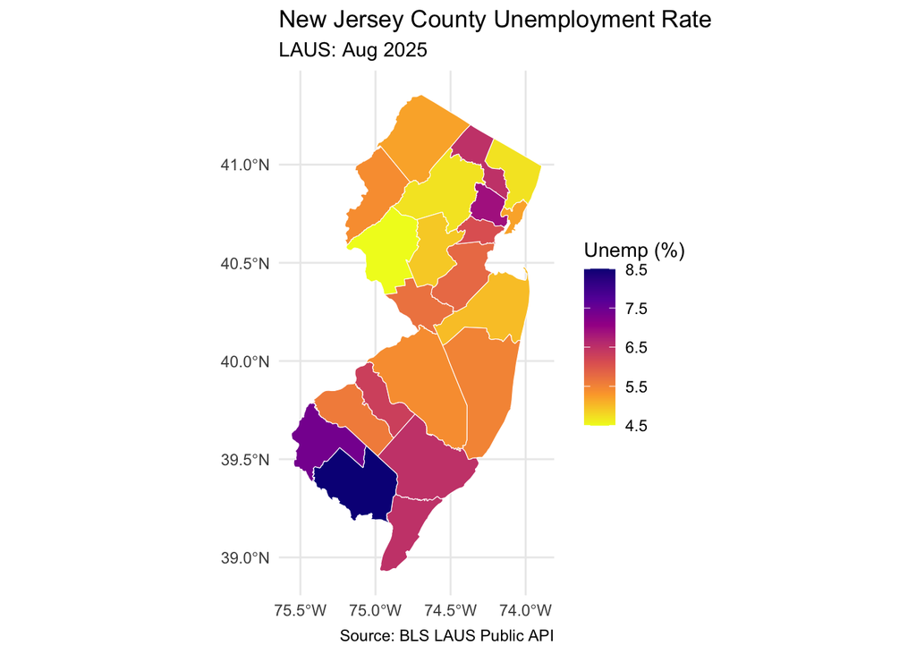

```r
ggplot(nj_unemp_geo, aes(fill = unemp_rate)) +
  geom_sf(color = "white") +
  scale_fill_viridis_c(option = "C", direction = -1) +
  labs(
    title = "New Jersey County Unemployment Rate",
    subtitle = paste("LAUS:", unique(nj_unemp_geo$period_lab)),
    fill = "Unemp (%)",
    caption = "Source: BLS LAUS Public API"
  ) +
  theme_minimal()
```

## Exercises

1. Change the state to **New York** (state FIPS = 36).
   - Get counties with `counties("NY")`
   - Build LAUS series with pattern `"LAUCN36"`
   - Map the unemployment rate
2. Use `scale_fill_gradient2()` and pick your own midpoint (e.g., 4%).

# 6. Interactive Mapping (Quick Tools)

### 6.1 mapview (1 line, instant map)

```r
mapview(nj_unemp_geo, zcol = "unemp_rate")
```

[interactive chart not shown]

### 6.2 tmap interactive mode

```r
tmap_mode("view")

tm_shape(nj_unemp_geo) +
  tm_polygons(col = "unemp_rate", palette = "inferno")
```

[interactive chart not shown]

```r
tmap_mode("plot")
```

# 7. Summary

This short, practical module provided:

- Core `sf` operations
- Basic mapping with `tigris` and `ggplot2`
- Easy ACS mapping with `tidycensus`
- Applied BLS unemployment mapping using LAUS API
- Static + interactive maps

This completes the core workflow for spatial analysis in labor market and economic development contexts.